# Ehsan Shaghaei B19-AAI01

# Task 1

Consider one dimensional actuated rotational body: $$ \phi '' = u $$ Assume that we apply the switching and rate feedback as follows: $$ u = −sign(kϕ + ϕ')$$ Draw the phase portrait of the system and determine convergence of the trajectories starting from $ϕ_0 > 0, ϕ_0 < 0$ and $ϕ_0 = 0$

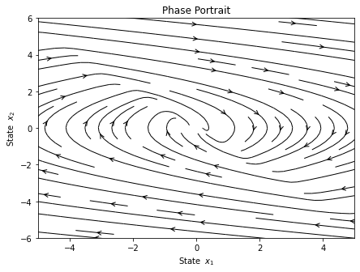

```python
from matplotlib.pyplot import *
def plotPhasePortrait(x_range,f,Title='Phase Portrait'):
    x1_max, x2_max = x_range
    # define the span for x1 and x2
    x1_span = linspace(-1.1*x1_max, 1.1*x1_max, 30)
    x2_span = linspace(-1.1*x2_max, 1.1*x2_max, 30)

    # Prepare the grid
    x1_grid, x2_grid = meshgrid(x1_span, x2_span)

    # calculate dxdt for grid points
    dx1, dx2 = f([x1_grid, x2_grid])

    # create the figure
    figure(figsize=(7, 5))
    # assign the title
    title(Title)

    # Draw the phase portrait
    streamplot(x1_span, x2_span, # span for x1, x2
            dx1, dx2, # the points calculated on grid
            arrowsize=1.2, # size of the arrows
            density=0.9, # density of the vectorfield
            color='k', # color for the trajectories
            linewidth=1, # the width of the lines for trajectories
            arrowstyle='->') # you can change type of arrows

    # Labels and limits for axes
    xlabel(r'State  $x_1$')
    ylabel(r'State  $x_2$')
    xlim([-x1_max, x1_max])
    ylim([-x2_max, x2_max])

import numpy as np
def f (state,k=1):
    phi,dphi = state
    ddphi=-1*np.sign(k*phi+dphi)
    return[dphi,ddphi]

from numpy import linspace, meshgrid

# define the range on which to draw phase portrait
x_range = [5,  # range for x_1
           6]  # range for x_2

plotPhasePortrait(x_range,f)
```

# TASK 2

Consider the linear two dimensional system in form: $x˙ = Ax, x ∈ R$ To study how the eigenvalues of A affect the phase portraits. Plot the different types of phase portraits (node, saddle, focus, center) with asociated complex plane representation of eigenvalues. Hint: Read the chapter 2.4 of Slotine’s textbook and repeat figure 2.

```python
from scipy.signal import place_poles

def plotComplex(s,Title):
    a,b=s
    if not type(a)==np.complex64:
        a = np.complex64(a)
    if not type(b)==np.complex64:
        b = np.complex64(b)
    xlabel('Real axis')
    ylabel('Imaginary axis')
    title('Complex numbers')
    axhline(y=0)
    axvline(x=0)
    xlim([-5, 5])
    ylim([-5, 5])
    scatter(b.real, b.imag, color="red", s=40)
    scatter(a.real, a.imag, color="red", s=40)
    show()

def foo(x, M):
    return M[0,0] * x[0] + M[0,1] * x[1], M[1,0] * x[0] + M[1,1] * x[1]
    # return M@x

#  (A-BK)


def plot_system_with_poles_and_pp(poles,Title):
    A=np.eye(2)
    B=np.eye(2)

    figure(figsize=(7, 5))
    K = A-B@place_poles(A, B, poles, 'YT').gain_matrix
    def paramSys(x):
        return foo(x,K)
    plotComplex(poles,Title+' Poles')
    plotPhasePortrait(x_range,paramSys,Title+" System PP")
```

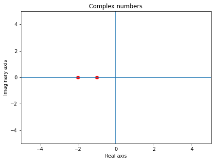

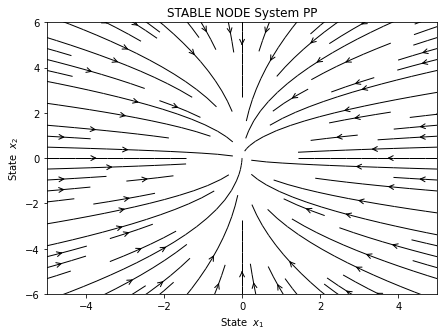

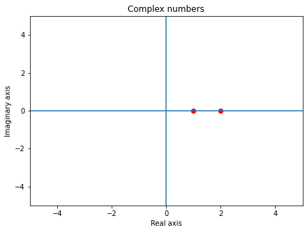

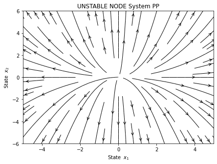

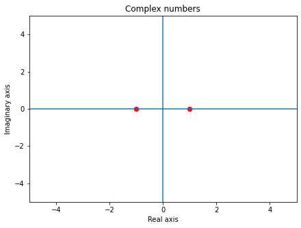

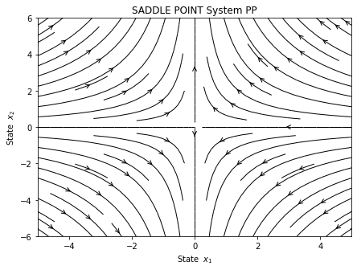

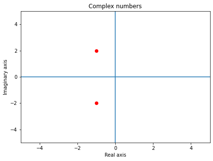

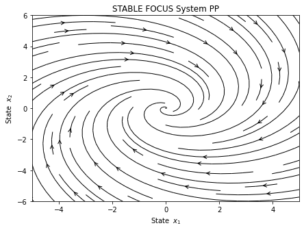

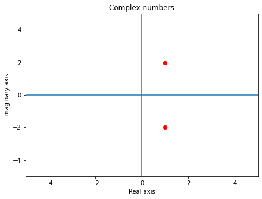

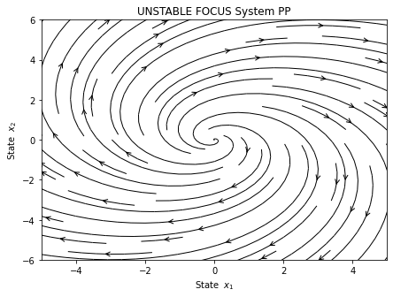

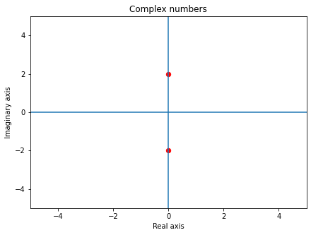

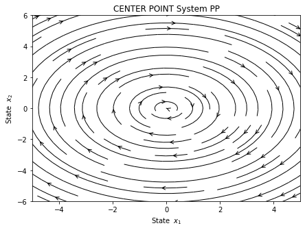

```python
pts ={
    "STABLE NODE":[-1,-2],
    "UNSTABLE NODE":[1,2],
    "SADDLE POINT":[-1,1],
    "STABLE FOCUS":[-1-2j,-1+2j],
    "UNSTABLE FOCUS":[1-2j,1+2j],
    "CENTER POINT":[2j,-2j]
}
for topic,poles in pts.items():
    plot_system_with_poles_and_pp(poles,topic)
```

# Task 3

Draw the associated phase portraits, and describe the behavior of system trajectories. Hint: use the figure 2.10 from the textbook.

## A

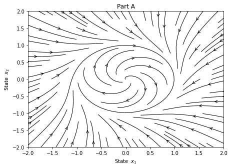

```python
def dx(x):
    return x[1]-x[0]*(x[0]**2+x[1]**2-1),\
            -x[0]-x[1]*(x[0]**2+x[1]**2-1)
plotPhasePortrait([2,2],dx,"Part A")
```

## B

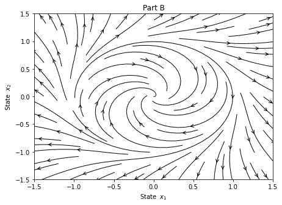

```python
def dx(x):
    return x[1]+x[0]*(x[0]**2+x[1]**2-1),\
        -x[0]+x[1]*(x[0]**2+x[1]**2-1)
plotPhasePortrait([1.5, 1.5], dx, "Part B")
```

## C

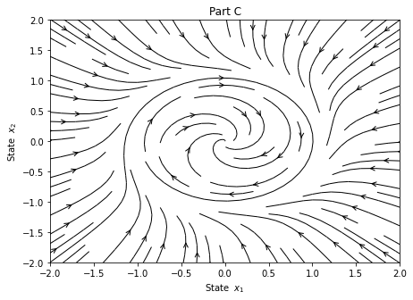

```python
def dx(x):
    return x[1]-x[0]*(x[0]**2+x[1]**2-1)**2,\
        -x[0]-x[1]*(x[0]**2+x[1]**2-1)**2
plotPhasePortrait([2, 2], dx, "Part C")
```

# TASK 4

Consider damped nonlinear pendulum with described by: $$x¨ = −x˙ − sin x$$ Find the equlibrium points and deduce their stability using Lyapunov linearization method

```python
from sympy import sin

def foo(st):
    dx,x = st
    return dx, -dx - sin(x)

from sympy import Matrix, symbols, solve
x = symbols(r'x_1, x_2')
f_sym = Matrix([foo(x)]).T
display('X\'=')
display(f_sym)

equlibriums = solve(f_sym, x)

display('Equilibrium=')
display(equlibriums)

jacobian = f_sym.jacobian(x)
display('Jacobian=',jacobian)

from sympy.utilities.lambdify import lambdify
from numpy import array

jacobian_num = lambdify([x], jacobian)

for equlibrium in equlibriums:
    x_e = array(equlibrium, dtype='double')
    A = array(jacobian_num(x_e), dtype='double')
    print(f'The matrix A for equlibrium {x_e} is: \n {A}')
```

```
"X'="
```

$\displaystyle \left[\begin{matrix}x_{1}\\- x_{1} - \sin{\left(x_{2} \right)}\end{matrix}\right]$

```
'Equilibrium='
```

```
[(0, 0), (0, pi)]
```

```
'Jacobian='
```

$\displaystyle \left[\begin{matrix}1 & 0\\-1 & - \cos{\left(x_{2} \right)}\end{matrix}\right]$

```
The matrix A for equlibrium [0. 0.] is:
 [[ 1.  0.]
 [-1. -1.]]
The matrix A for equlibrium [0.         3.14159265] is:
 [[ 1.  0.]
 [-1.  1.]]
```

# Task 5

Implement software routine that will implement the Lyapunov linearization method including:

- Solving for equlibrium
- Symbolical linearization
- Checking for the stability of each equlibrium
- Drawing the phase portrait together with stable and unstable points. Test developed routine on following system: $$x_1^\prime = x_1 − x_1^3 + 2 x_1 x_2$$ $$x_2^\prime = −x_2 + 1/2 \times x_1 x_2$$

```
"X'="
```

$\displaystyle \left[\begin{matrix}- x_{1}^{3} + 2 x_{1} x_{2} + x_{1}\\0.5 x_{1} x_{2} - x_{2}\end{matrix}\right]$

```
'Equilibrium='
```

```
[(-1.00000000000000, 0.0),
 (0.0, 0.0),
 (1.00000000000000, 0.0),
 (2.00000000000000, 1.50000000000000)]
```

```
'Jacobian='
```

$\displaystyle \left[\begin{matrix}- 3 x_{1}^{2} + 2 x_{2} + 1 & 2 x_{1}\\0.5 x_{2} & 0.5 x_{1} - 1\end{matrix}\right]$

```
The matrix A for equlibrium [-1.  0.] is:
 [[-2.  -2. ]
 [ 0.  -1.5]]
The matrix A for equlibrium [0. 0.] is:
 [[ 1.  0.]
 [ 0. -1.]]
The matrix A for equlibrium [1. 0.] is:
 [[-2.   2. ]
 [ 0.  -0.5]]
The matrix A for equlibrium [2.  1.5] is:
 [[-8.    4.  ]
 [ 0.75  0.  ]]
```

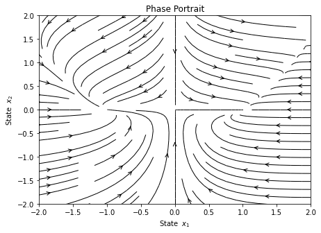

```python
from sympy import sin

def foo(st):
    x1,x2 = st
    return x1 - x1**3 + 2*x1*x2,-x2+(1/2)*x1*x2

from sympy import Matrix, symbols, solve
x = symbols(r'x_1, x_2')
f_sym = Matrix([foo(x)]).T
display('X\'=')
display(f_sym)

equlibriums = solve(f_sym, x)

display('Equilibrium=')
display(equlibriums)

jacobian = f_sym.jacobian(x)
display('Jacobian=',jacobian)

from sympy.utilities.lambdify import lambdify
from numpy import array

jacobian_num = lambdify([x], jacobian)

for equlibrium in equlibriums:
    x_e = array(equlibrium, dtype='double')
    A = array(jacobian_num(x_e), dtype='double')
    print(f'The matrix A for equlibrium {x_e} is: \n {A}')

plotPhasePortrait([2,2],foo)
```